# ISYE 6402 Final project ETH analysis(daily) ARIMA

# Background

```r
library(lubridate)
library(mgcv)
library(tseries)
library(zoo)
library(mgcv)
library(TSA)
library(dynlm)
library(ggplot2)
library(reshape2)
library(greybox)
library(mlr)
library(lubridate)
library(dplyr)
library(data.table)
library(forecast)
```

**Part 1: EDA**

```r
#Initialize plot color
c.col<-"#20B2AA"
data.daily <- read.csv("ETH.csv", head = TRUE)
setnames(data.daily, tolower(names(data.daily)))
ts.start=c(2020,7,7)
data.daily$month <- format(as.Date(data.daily$date, format="%Y-%m-%d"),"%B")
data.daily$weekday <- as.character(lubridate::wday(data.daily$date, label=FALSE, abbr=FALSE))
data.daily$monthday <- format(as.Date(data.daily$date, format="%Y-%m-%d"),"%d")
daily.ts<-ts(log(data.daily$close),start=ts.start,freq = 365.25)
```

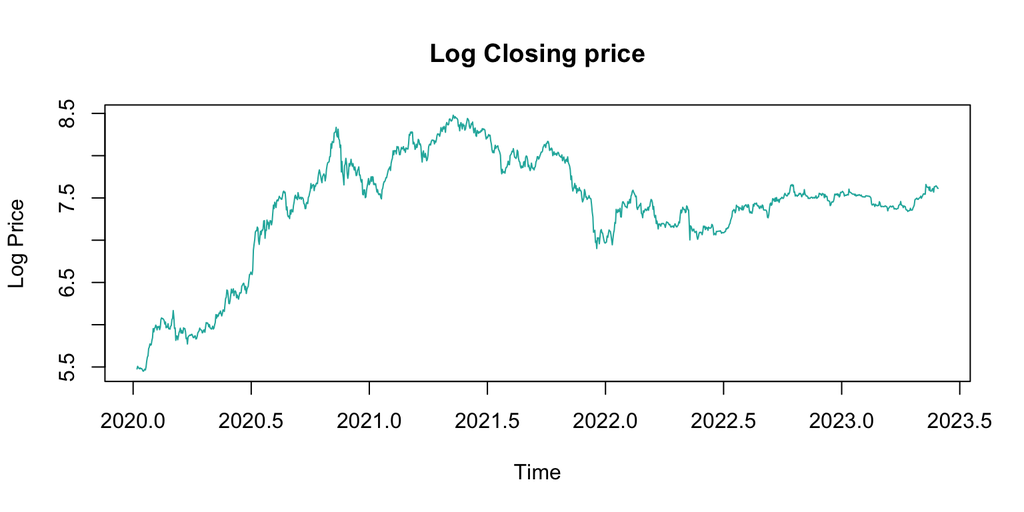

```r
ts.plot(daily.ts,ylab="Log Price",main='Log Closing price',col=c.col)
```

### Decomposition

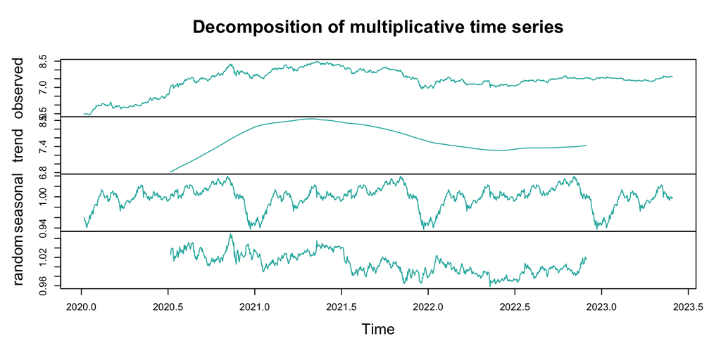

```r
plot(decompose(daily.ts, "multiplicative"),col=c.col)
```

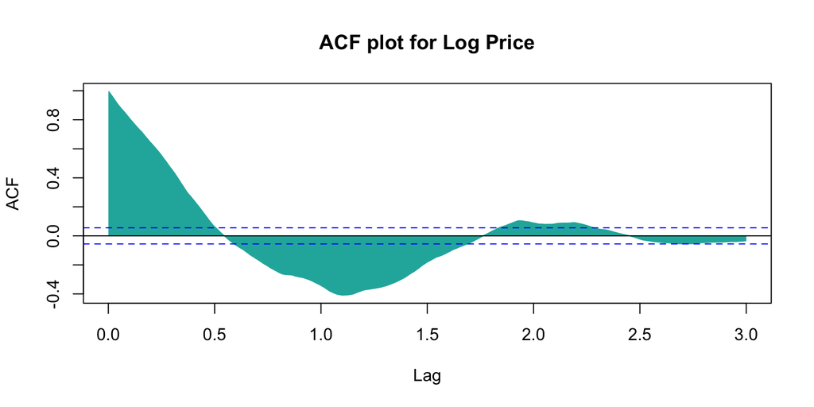

```r
acf(daily.ts,lag.max=365*3,main="ACF plot for Log Price",col=c.col)
```

*Result*:

From looking at the time series plots we can see an increasing, then decreasing and again increasing trend as well as some seasonal patterns. The acf plot confirms the trend as well as some seasonal patterns. The time series isn’t stationary.

### Differenced data

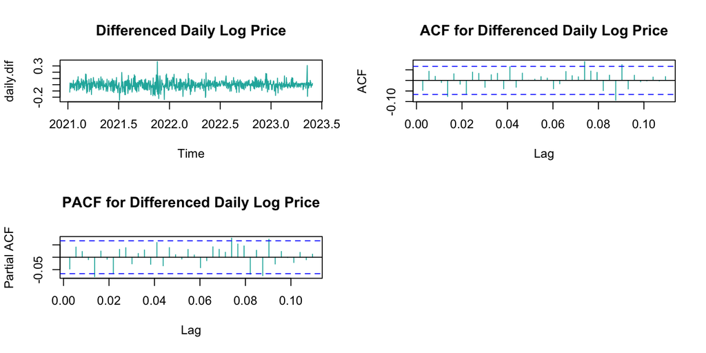

```r
#Data difference
par(mfrow=c(2,2))
daily.dif=diff(diff(daily.ts,1),365)
n = length(daily.dif)
nfit = n-14
daily.dif.train = daily.dif[1:nfit]
plot(daily.dif,main='Differenced Daily Log Price',col=c.col)
acf(daily.dif,main='ACF for Differenced Daily Log Price',lag.max=40,col=c.col)
pacf(daily.dif,main='PACF for Differenced Daily Log Price',lag.max=40,col=c.col)
```

```r
adf.test(daily.dif)
```

```
##
##  Augmented Dickey-Fuller Test
##
## data:  daily.dif
## Dickey-Fuller = -9.5843, Lag order = 9, p-value = 0.01
## alternative hypothesis: stationary
```

We can see that the differenced data in terms of trend and seasonality might be stationary since most of the values on the acf and pacf plots are within the confidence bands.

**Part 2: non-parametric trend using splines and monthly seasonality using ANOVA** Fit the daily price with a non-parametric trend using splines and monthly seasonality using ANOVA.

```r
## Fit a non-parametric model for trend and ANOVA model for seasonality
daily.time.pts = c(1:length(daily.ts))
length(daily.time.pts)
```

```
## [1] 1240
```

```r
daily.gam.fit = gam(daily.ts~s(daily.time.pts) + data.daily$month + data.daily$weekday+data.daily$monthday)
summary(daily.gam.fit)
```

```
##
## Family: gaussian
## Link function: identity
##
## Formula:
## daily.ts ~ s(daily.time.pts) + data.daily$month + data.daily$weekday +
##     data.daily$monthday
##
## Parametric coefficients:
##                             Estimate Std. Error t value Pr(>|t|)
## (Intercept)                7.8183758  0.0431696 181.108  < 2e-16 ***
## data.daily$monthAugust    -0.4561409  0.0539155  -8.460  < 2e-16 ***
## data.daily$monthDecember  -0.5700749  0.0571735  -9.971  < 2e-16 ***
## data.daily$monthFebruary  -0.2019386  0.0375411  -5.379 9.01e-08 ***
## data.daily$monthJanuary   -0.3722751  0.0480564  -7.747 2.02e-14 ***
## data.daily$monthJuly      -0.5701288  0.0479180 -11.898  < 2e-16 ***
## data.daily$monthJune      -0.4259962  0.0366879 -11.611  < 2e-16 ***
## data.daily$monthMarch     -0.1595211  0.0263509  -6.054 1.90e-09 ***
## data.daily$monthMay       -0.0811881  0.0262213  -3.096  0.00201 **
## data.daily$monthNovember  -0.5672558  0.0638174  -8.889  < 2e-16 ***
## data.daily$monthOctober   -0.6630456  0.0622736 -10.647  < 2e-16 ***
## data.daily$monthSeptember -0.6169529  0.0587990 -10.493  < 2e-16 ***
## data.daily$weekday2       -0.0031136  0.0150454  -0.207  0.83609
## data.daily$weekday3       -0.0036863  0.0150369  -0.245  0.80638
## data.daily$weekday4       -0.0007289  0.0150557  -0.048  0.96139
## data.daily$weekday5       -0.0003415  0.0150552  -0.023  0.98190
## data.daily$weekday6       -0.0018303  0.0150535  -0.122  0.90325
## data.daily$weekday7       -0.0014442  0.0150415  -0.096  0.92353
## data.daily$monthday02     -0.0003147  0.0316082  -0.010  0.99206
## data.daily$monthday03      0.0070256  0.0316084   0.222  0.82414
## data.daily$monthday04      0.0137118  0.0316087   0.434  0.66451
## data.daily$monthday05      0.0150460  0.0316090   0.476  0.63416
## data.daily$monthday06      0.0186564  0.0316095   0.590  0.55516
## data.daily$monthday07      0.0069343  0.0314185   0.221  0.82536
## data.daily$monthday08      0.0066114  0.0314117   0.210  0.83333
## data.daily$monthday09      0.0033482  0.0314207   0.107  0.91515
## data.daily$monthday10     -0.0043156  0.0314232  -0.137  0.89079
## data.daily$monthday11     -0.0143967  0.0314215  -0.458  0.64691
## data.daily$monthday12     -0.0176661  0.0314243  -0.562  0.57410
## data.daily$monthday13     -0.0124214  0.0314252  -0.395  0.69272
```

[output cut: 14 more lines]

```
## data.daily$monthday28     -0.0357196  0.0314530  -1.136  0.25633
## data.daily$monthday29     -0.0252857  0.0323148  -0.782  0.43409
## data.daily$monthday30     -0.0150679  0.0323326  -0.466  0.64128
## data.daily$monthday31      0.0141469  0.0367215   0.385  0.70012
## ---
## Signif. codes:  0 '***' 0.001 '**' 0.01 '*' 0.05 '.' 0.1 ' ' 1
##
## Approximate significance of smooth terms:
##                     edf Ref.df    F p-value
## s(daily.time.pts) 8.874  8.993 2590  <2e-16 ***
## ---
## Signif. codes:  0 '***' 0.001 '**' 0.01 '*' 0.05 '.' 0.1 ' ' 1
##
## R-sq.(adj) =  0.955   Deviance explained = 95.7%
## GCV = 0.02093  Scale est. = 0.01997   n = 1240
```

```r
## Fit a non-parametric model for trend and ANOVA model for seasonality
daily.time.pts = c(1:length(daily.ts))
length(daily.time.pts)
```

```
## [1] 1240
```

```r
daily.gam.fit = gam(daily.ts~s(daily.time.pts) + data.daily$month)
summary(daily.gam.fit)
```

```
##
## Family: gaussian
## Link function: identity
##
## Formula:
## daily.ts ~ s(daily.time.pts) + data.daily$month
##
## Parametric coefficients:
##                           Estimate Std. Error t value Pr(>|t|)
## (Intercept)                7.79144    0.03502 222.464  < 2e-16 ***
## data.daily$monthAugust    -0.45300    0.05357  -8.456  < 2e-16 ***
## data.daily$monthDecember  -0.54553    0.05647  -9.660  < 2e-16 ***
## data.daily$monthFebruary  -0.18708    0.03702  -5.054 4.99e-07 ***
## data.daily$monthJanuary   -0.35081    0.04745  -7.394 2.64e-13 ***
## data.daily$monthJuly      -0.57477    0.04757 -12.082  < 2e-16 ***
## data.daily$monthJune      -0.43249    0.03643 -11.871  < 2e-16 ***
## data.daily$monthMarch     -0.15132    0.02615  -5.787 9.09e-09 ***
## data.daily$monthMay       -0.08528    0.02602  -3.278  0.00108 **
## data.daily$monthNovember  -0.54317    0.06308  -8.611  < 2e-16 ***
## data.daily$monthOctober   -0.64390    0.06171 -10.434  < 2e-16 ***
## data.daily$monthSeptember -0.60663    0.05838 -10.390  < 2e-16 ***
## ---
## Signif. codes:  0 '***' 0.001 '**' 0.01 '*' 0.05 '.' 0.1 ' ' 1
##
## Approximate significance of smooth terms:
##                     edf Ref.df    F p-value
## s(daily.time.pts) 8.863  8.992 2606  <2e-16 ***
## ---
## Signif. codes:  0 '***' 0.001 '**' 0.01 '*' 0.05 '.' 0.1 ' ' 1
##
## R-sq.(adj) =  0.955   Deviance explained = 95.6%
## GCV = 0.020172  Scale est. = 0.019832  n = 1240
```

We can see that the monthly seasonality is significant, while day of the week and day of the month aren’t significant. The trend is significant.

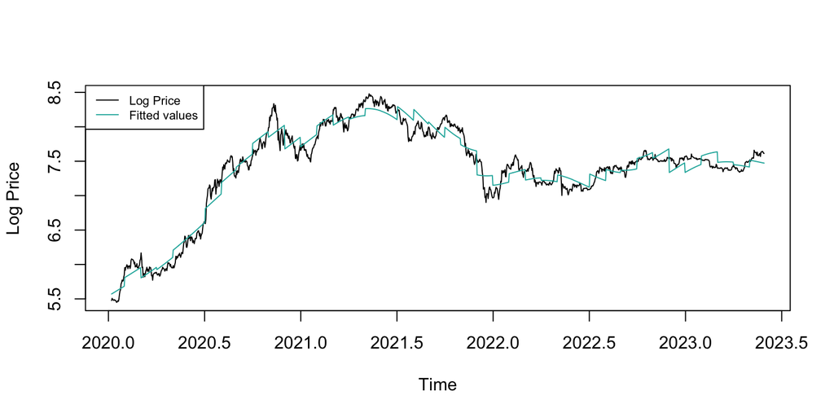

```r
plot(daily.ts,ylab="Log Price",col="black")
lines(ts((fitted(daily.gam.fit)),start=ts.start, freq = 365.25),col=c.col)
legend(x="topleft",legend=c("Log Price","Fitted values"), lty=1,col=c("black",c.col),cex=0.7)
```

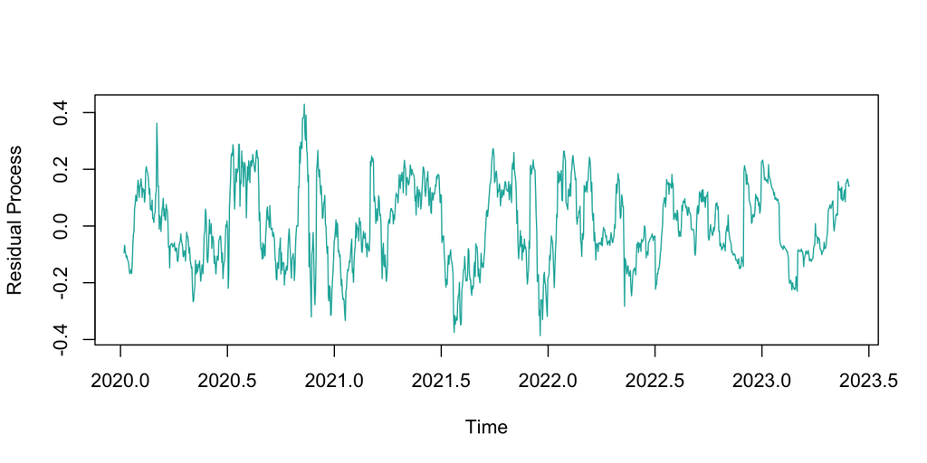

```r
daily.dif.fit.gam = ts((daily.ts-fitted(daily.gam.fit)),start=ts.start, freq = 365.25)
ts.plot(daily.dif.fit.gam,ylab="Residual Process",col=c.col)
```

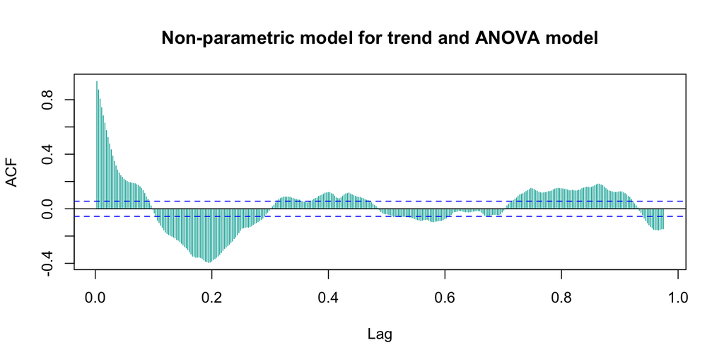

```r
acf(daily.dif.fit.gam,lag.max=356,main="Non-parametric model for trend and ANOVA model",col=c.col)
```

```r
adf.test(daily.dif.fit.gam)
```

```
##
##  Augmented Dickey-Fuller Test
##
## data:  daily.dif.fit.gam
## Dickey-Fuller = -6.4594, Lag order = 10, p-value = 0.01
## alternative hypothesis: stationary
```

*Response:*

Looking at the fitted values plot we can see that overall our model does fit most of the patterns in the data. However, our model didn’t fit several picks in the data which is confirmed by the residual plot. Looking at the acf plot we can see seasonal patterns.

**Part 3 (ARMA fitting and order selection).**

```r
## Fit an ARMA model to the difference time series
norder = 11
#Iterative function
test_modelA <- function(p,q,data){
  mod = Arima(data,order=c(p,0,q),method="ML")
  current.aic = AIC(mod)
  df = data.frame(p,q,current.aic)
  names(df) <- c("p","q","AIC")
  #print(paste(p,d,q,current.aic,sep=" "))
  return(df)
}

orders = data.frame(Inf,Inf,Inf)
names(orders) <- c("p","q","AIC")

#Orders for DAL
for (p in 0:norder){
    for (q in 0:norder) {
      possibleError <- tryCatch(
        orders<-rbind(orders,test_modelA(p,q,daily.dif.train)),
        error=function(e) e
      )
      if(inherits(possibleError, "error")) next

    }
}
orders <- orders[order(-orders$AIC),]
tail(orders,5)
```

```
##    p q       AIC
## 43 3 5 -2277.656
## 64 5 2 -2277.929
## 28 2 2 -2278.666
## 31 2 5 -2278.848
## 30 2 4 -2279.540
```

```r
# The optimal value according to the AIC
porder <- tail(orders,1)$p
qorder <- tail(orders,1)$q
aic_value <- tail(orders,1)$AIC
```

```r
cat("Order of the selected model is: AR order p =", porder, "; MA order q =", qorder)
```

```
## Order of the selected model is: AR order p = 2 ; MA order q = 4
```

```r
cat(" The best model AIC is", aic_value)
```

```
##  The best model AIC is -2279.54
```

```r
# Fit the "best" arima model
final_model <- Arima(daily.dif.train, order = c(porder,0,qorder), method = "ML")
```

```r
final_model
```

```
## Series: daily.dif.train
## ARIMA(2,0,4) with non-zero mean
##
## Coefficients:
##           ar1      ar2     ma1     ma2     ma3     ma4     mean
##       -0.9992  -0.8760  0.9645  0.8935  0.0587  0.1038  -0.0021
## s.e.   0.0704   0.0735  0.0763  0.0857  0.0511  0.0364   0.0023
##
## sigma^2 = 0.00409:  log likelihood = 1147.77
## AIC=-2279.54   AICc=-2279.37   BIC=-2241.49
```

```r
coef(final_model)[1:porder]
```

```
##        ar1        ar2
## -0.9992483 -0.8759651
```

```r
# All absolute values are greater than 1 => Causal
abs.roots<-list()
for (root in c(polyroot(c(1,-c(coef(final_model)[1:porder]))))){
 abs.roots<-append(abs.roots,abs(root))
}
abs.roots
```

```
## [[1]]
## [1] 1.068456
##
## [[2]]
## [1] 1.068456
```

```r
final_model$coef
```

```
##          ar1          ar2          ma1          ma2          ma3          ma4
## -0.999248332 -0.875965148  0.964529645  0.893522980  0.058689285  0.103817608
##    intercept
## -0.002107152
```

```r
## compute the test statistics
testval <-
  as.numeric(final_model$coef) / as.numeric(sqrt(diag(final_model$var.coef)))
abs(testval)>qnorm((1-0.05/2))
```

```
## [1]  TRUE  TRUE  TRUE  TRUE FALSE  TRUE FALSE
```

```r
which(abs(testval)>qnorm((1-0.05/2)))
```

```
## [1] 1 2 3 4 6
```

*Result*:

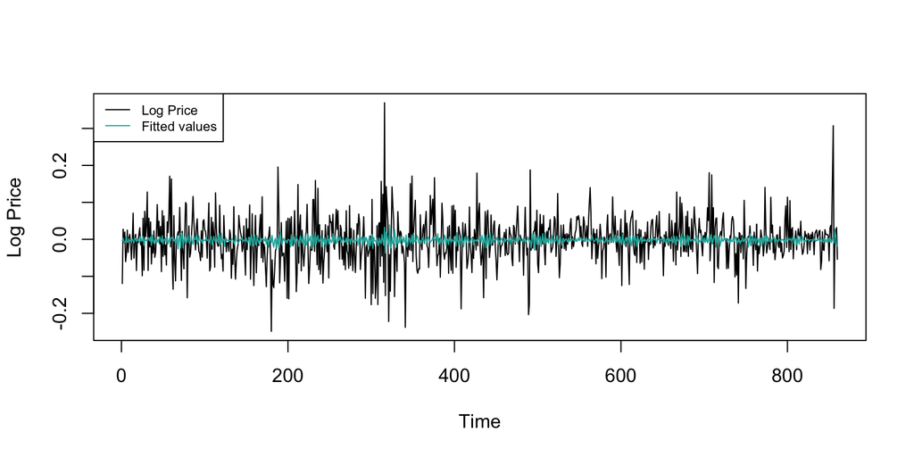

```r
ts.plot(daily.dif.train,ylab="Log Price",col="black")
lines(fitted(final_model),col=c.col)
legend(x="topleft",legend=c("Log Price","Fitted values"), lty=1,col=c("black",c.col),cex=0.7)
```

From the fitted values plot we can see that the model failed to fit the data and there is a lot of variance that wasn’t captured by the model.

**Residual analysis**

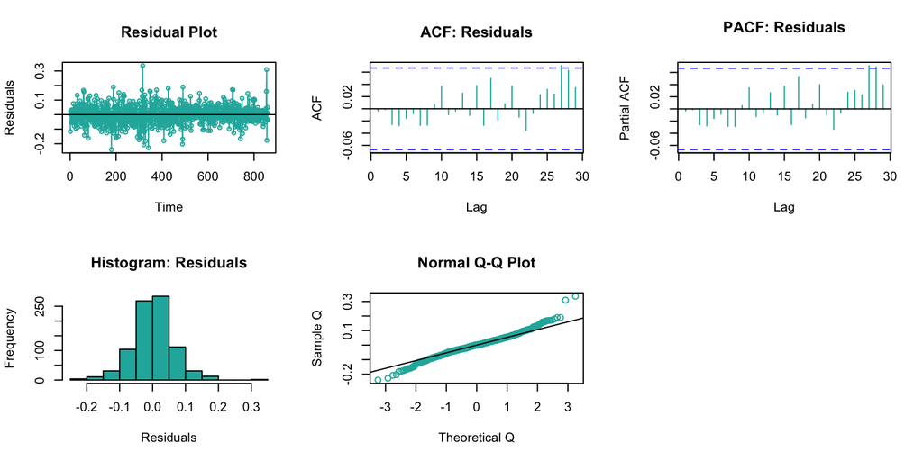

```r
## Residual analysis
par(mfrow=c(2,3))
resids <- resid(final_model)
plot(resids, ylab='Residuals',type='o',main="Residual Plot",col=c.col)
abline(h=0)
acf(resids,main="ACF: Residuals",col=c.col)
pacf(resids, main="PACF: Residuals",col=c.col)
hist(resids,xlab='Residuals',main='Histogram: Residuals',col=c.col)
qqnorm(resids,ylab="Sample Q",xlab="Theoretical Q",col=c.col)
qqline(resids)
```

*Results*: The residual plot for the model doesn’t show a pattern. However, the variance of the residuals doesn’t seem to be constant. The acf plots show that most of the values lie inside the confidence bands. The same is for PACF plots: most of the values lie within the confidence bands. The QQ-norm plots show left and right heavy tails: which indicates that the distribution has heavier tails than the normal. We can also see several outliers. Other than that, the residuals look pretty symmetric. Overall, the model doesn’t satisfy the R implementation since the residual process isn’t normally distributed with constant variance.

**Testing uncorrelated residuals**

```r
# Test and see if residuals are correlated
Box.test(final_model$resid, lag = (porder+qorder+1), type = "Ljung-Box", fitdf = (porder+qorder))
```

```
##
##  Box-Ljung test
##
## data:  final_model$resid
## X-squared = 2.1572, df = 1, p-value = 0.1419
```

*Results*:

The null hypothesis for Ljung-Box test is that the residuals are uncorrelated. Since we can see that we got a pretty high p-value (greater than 0.05), it indicates that we can not reject the null hypothesis and our residuals are probably uncorrelated.

```r
# Test for arch effect
Box.test(final_model$resid^2, lag = (porder+qorder+1), type = "Ljung-Box", fitdf = (porder+qorder))
```

```
##
##  Box-Ljung test
##
## data:  final_model$resid^2
## X-squared = 52.2, df = 1, p-value = 5.014e-13
```

```r
#perform shapiro-wilk test: null hypothesis: normal
shapiro.test(residuals(final_model))
```

```
##
##  Shapiro-Wilk normality test
##
## data:  residuals(final_model)
## W = 0.98041, p-value = 2.459e-09
```

```r
adf.test(final_model$resid)
```

```
##
##  Augmented Dickey-Fuller Test
##
## data:  final_model$resid
## Dickey-Fuller = -9.659, Lag order = 9, p-value = 0.01
## alternative hypothesis: stationary
```

We can see that the residual process doesn’t seem to have constant variance. Test for heteroscedasticity (arch effect) confirms that the variance changes with time(we reject the null hypothesis that there is no arch effect).

From the QQ-plot and Shapiro-Wilk normality test follow that the residual process isn’t normally distributed.

ACF plot doesn’t show correlations since most of the values are inside the confidence band.

Augmented Dickey-Fuller Test shows that the residual processes is stationary.

Since the variance isn’t constant and the normality assumption of the residuals is violated our model doesn’t provide a good fit (normal distribution is required for model fitting using MLE).

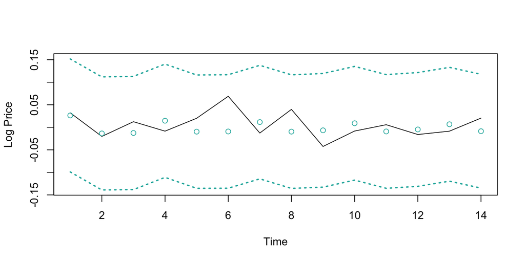

```r
## Forecasting with ARIMA: 9 Weeks Ahead
out_pred = as.vector(predict(final_model,n.ahead=n-nfit))
ubound = out_pred$pred+1.96*out_pred$se
lbound = out_pred$pred-1.96*out_pred$se
ymin = min(lbound)
ymax = max(ubound)
par(mfrow=c(1,1))
plot(ts(daily.dif[nfit+1:n][1:(n-nfit)],start=1),type="l", ylim=c(ymin,ymax), xlab="Time", ylab="Log Price")
points(ts(out_pred$pred,start=1),col=c.col)
lines(ts(ubound,start=1),lty=3,lwd= 2, col=c.col)
lines(ts(lbound,start=1),lty=3,lwd= 2, col=c.col)
```

```r
cat("MAE:",mean(abs(out_pred$pred-daily.dif[nfit+1:n][1:(n-nfit)])),"\n PM:",
sum((out_pred$pred-daily.dif[nfit+1:n][1:(n-nfit)])^2)/sum((daily.dif[nfit+1:n][1:(n-nfit)]-mean(daily.dif[nfit+1:n][1:(n-nfit)]))^2))
```

```
## MAE: 0.02612691
##  PM: 1.329514
```

```r
# Arima with Harmonic trend
n = length(data.daily$date)
nfit = n-14
training.month <- lubridate::month(as.Date(data.daily$date, format="%Y-%m-%d"),label=FALSE)[1:nfit]
test.month<- lubridate::month(as.Date(data.daily$date, format="%Y-%m-%d"),label=FALSE)[nfit+1:n]
training.weekday <- lubridate::wday(data.daily$date, label=FALSE, abbr=FALSE)[1:nfit]
test.weekday <- lubridate::wday(data.daily$date, label=FALSE, abbr=FALSE)[nfit+1:n]
```

```r
harmonic.train <- cbind(sin(training.weekday*2*pi/7),cos(training.weekday*2*pi/7),sin(training.month*2*pi/12),cos(training.month*2*pi/12))
daily.ts.train = ts(daily.ts[1:nfit],start=ts.start,freq = 365.25)
test_modelA <- function(p,d,q){
  mod = Arima(daily.ts.train,order=c(p,d,q),xreg=as.matrix(harmonic.train))
  current.aic = AIC(mod)
  current.bic = BIC(mod)
  df = data.frame(p,d,q,current.aic,current.bic)
  names(df) <- c("p","d","q","AIC","BIC")
  #print(paste(p,d,q,current.aic,sep=" "))
  return(df)
}
```

```r
library(forecast)
orders = data.frame(Inf,Inf,Inf,Inf,Inf)
names(orders) <- c("p","d","q","AIC","BIC")

for (p in 0:10){
  for (d in 0:1){
    for (q in 0:10){
      possibleError <- tryCatch(
        orders<-rbind(orders,test_modelA(p,d,q)),
        error=function(e) e
      )
      if(inherits(possibleError, "error")) next
    }
  }
}
orders <- orders[order(-orders$AIC),]
tail(orders)
```

```
##     p d q       AIC       BIC
## 102 4 1 3 -4157.701 -4096.373
## 63  2 1 6 -4157.727 -4091.287
## 60  2 1 3 -4157.947 -4106.840
## 81  3 1 2 -4157.986 -4106.879
## 59  2 1 2 -4159.367 -4113.371
## 171 7 1 7 -4161.767 -4064.664
```

```r
orders1 <- orders[order(-orders$BIC),]
tail(orders1)
```

```
##    p d q       AIC       BIC
## 36 1 1 1 -4149.274 -4113.499
## 57 2 1 0 -4149.579 -4113.804
## 15 0 1 2 -4149.743 -4113.968
## 14 0 1 1 -4149.490 -4118.826
## 35 1 1 0 -4149.607 -4118.943
## 13 0 1 0 -4150.083 -4124.529
```

```r
#porder <- tail(orders,2)$p[1]
#qorder <- tail(orders,2)$q[1]
#dorder <- tail(orders,2)$d[1]
#aic_value <- tail(orders,2)$AIC[1]
porder <- tail(orders1,2)$p[1]
qorder <- tail(orders1,2)$q[1]
dorder <- tail(orders1,2)$d[1]
aic_value <- tail(orders,2)$AIC[1]
bic_value <- tail(orders,2)$BIC[1]
cat("Order of the selected model is: AR order p =", porder, "; MA order q =", qorder, "dorder d =", dorder)
```

```
## Order of the selected model is: AR order p = 1 ; MA order q = 0 dorder d = 1
```

```r
cat(" The best model AIC is", aic_value)
```

```
##  The best model AIC is -4159.367
```

```r
cat(" The best model BIC is", bic_value)
```

```
##  The best model BIC is -4113.371
```

```r
# Fit the "best" arima model
final_model1 <- Arima(daily.ts.train, order=c(porder,dorder,qorder), xreg=as.matrix(harmonic.train))
final_model1
```

```
## Series: daily.ts.train
## Regression with ARIMA(1,1,0) errors
##
## Coefficients:
##           ar1  xreg1   xreg2   xreg3   xreg4
##       -0.0353  9e-04  -0.001  0.0116  0.0039
## s.e.   0.0286  2e-03   0.002  0.0195  0.0187
##
## sigma^2 = 0.001967:  log likelihood = 2080.8
## AIC=-4149.61   AICc=-4149.54   BIC=-4118.94
```

```r
coef(final_model1)
```

```
##           ar1         xreg1         xreg2         xreg3         xreg4
## -0.0352726206  0.0009362205 -0.0010083611  0.0116425037  0.0039317269
```

```r
# All absolute values are greater than 1 => Causal
abs.roots<-list()
for (root in c(polyroot(c(1,-c(coef(final_model1)[1:porder]))))){
 abs.roots<-append(abs.roots,abs(root))
}
abs.roots
```

```
## [[1]]
## [1] 28.3506
```

```r
## compute the test statistics
testval <-
  as.numeric(final_model1$coef) / as.numeric(sqrt(diag(final_model1$var.coef)))
abs(testval)>qnorm((1-0.05/2))
```

```
## [1] FALSE FALSE FALSE FALSE FALSE
```

```r
which(abs(testval)>qnorm((1-0.05/2)))
```

```
## integer(0)
```

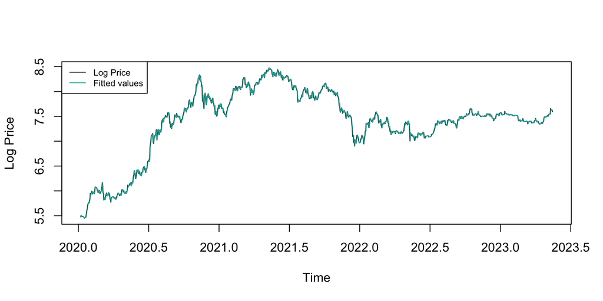

```r
ts.plot(daily.ts.train,ylab="Log Price",col="black")
lines(ts((fitted(final_model1)),start=ts.start, freq = 365.25),col=c.col)
legend(x="topleft",legend=c("Log Price","Fitted values"), lty=1,col=c("black",c.col),cex=0.7)
```

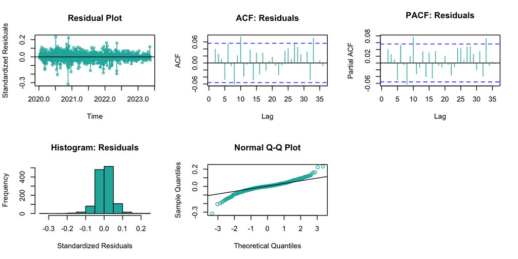

```r
# residual analysis
par(mfrow=c(2,3))
plot(resid(final_model1), ylab='Standardized Residuals',type='o',main="Residual Plot",col=c.col)
abline(h=0)
acf(as.vector(resid(final_model1)),lag.max=36,main="ACF: Residuals",col=c.col)
pacf(as.vector(resid(final_model1)),lag.max=36,main="PACF: Residuals",col=c.col)
hist(resid(final_model1),xlab='Standardized Residuals',main='Histogram: Residuals',col=c.col)
qqnorm(resid(final_model1),col=c.col)
qqline(resid(final_model1))
```

**Testing uncorrelated residuals**

```r
# Test and see if residuals are correlated
Box.test(final_model1$resid, lag = (porder+qorder+1), type = "Ljung-Box", fitdf = (porder+qorder))
```

```
##
##  Box-Ljung test
##
## data:  final_model1$resid
## X-squared = 1.9142, df = 1, p-value = 0.1665
```

*Results*:

The null hypothesis for Ljung-Box test is that the residuals are uncorrelated. Since we can see that we got a pretty high p-value, it indicates that we don’t reject the null hypothesis and our residuals are probably uncorrelated.

```r
# Test for arch effect
Box.test(final_model1$resid^2, lag = (porder+qorder+1), type = "Ljung-Box", fitdf = (porder+qorder))
```

```
##
##  Box-Ljung test
##
## data:  final_model1$resid^2
## X-squared = 50.356, df = 1, p-value = 1.282e-12
```

```r
#perform shapiro-wilk test: null hypothesis: normal
shapiro.test(residuals(final_model1))
```

```
##
##  Shapiro-Wilk normality test
##
## data:  residuals(final_model1)
## W = 0.94359, p-value < 2.2e-16
```

```r
adf.test(final_model1$resid)
```

```
##
##  Augmented Dickey-Fuller Test
##
## data:  final_model1$resid
## Dickey-Fuller = -10.325, Lag order = 10, p-value = 0.01
## alternative hypothesis: stationary
```

We can see that the residual process doesn’t seem to have constant variance. Test for heteroscedasticity (arch effect) confirms that the variance changes with time(we reject the null hypothesis that there is no arch effect).

From the QQ-plot and Shapiro-Wilk normality test follow that the residual process isn’t normally distributed.

ACF plot doesn’t show correlations since most of the values are inside the confidence band.

Augmented Dickey-Fuller Test shows that the residual processes is stationary.

Since the variance isn’t constant and the normality assumption of the residuals is violated our model doesn’t provide a good fit (normal distribution is required for model fitting using MLE).

** Predictions * N-ahead prediction ***

```r
harmonic.test <- cbind(sin(test.weekday*2*pi/7),cos(test.weekday*2*pi/7),sin(test.month*2*pi/12),cos(test.month*2*pi/12))
daily.ts.test=daily.ts[nfit+1:n][1:(n-nfit)]
pred=predict(final_model1,n.ahead=14,newxreg=as.matrix(harmonic.test),ci=0.95)
```

```r
arma.cnt = pred$pred[1:14]
arma.cnt.ts = ts(arma.cnt,start=1)
lo.arma.cnt = ts(arma.cnt-1.96*pred$se,start=1)
up.arma.cnt = ts(arma.cnt+1.96*pred$se,start=1)
```

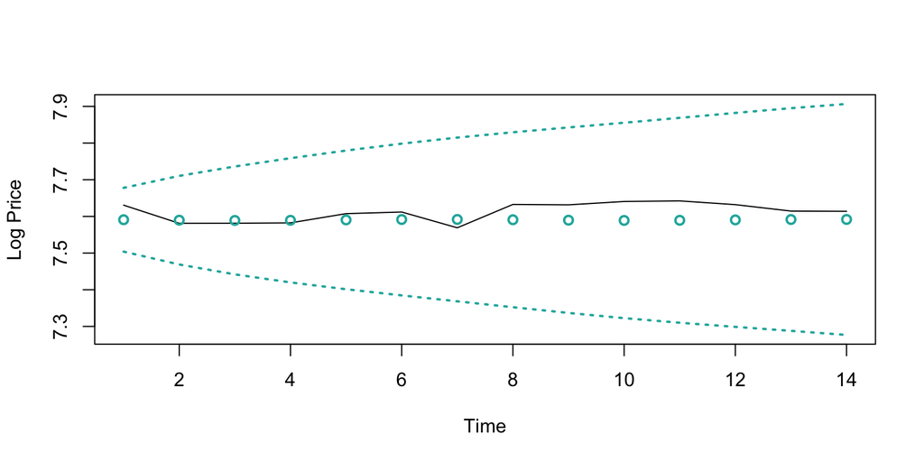

```r
ymin=min(daily.ts.test,arma.cnt.ts,lo.arma.cnt,up.arma.cnt)
ymax=max(daily.ts.test,arma.cnt.ts,lo.arma.cnt,up.arma.cnt)
par(mfrow=c(1,1))
plot(ts(daily.ts.test,start=1), ylim=c(ymin,ymax), ylab="Log Price", type="l",main="")
points(arma.cnt.ts,lwd=2,col=c.col)
lines(lo.arma.cnt,lty=3,lwd= 2, col=c.col)
lines(up.arma.cnt,lty=3,lwd= 2, col=c.col)
```

```r
cat("MAE:",mean(abs(arma.cnt-daily.ts.test)),"\n PM:",
sum((arma.cnt-daily.ts.test)^2)/sum((daily.ts.test-mean(daily.ts.test))^2))
```

```
## MAE: 0.02843593
##  PM: 1.850336
```

*** Rolling predictions ***

```r
nfore = n-nfit
fore.series = NULL
fore.se = NULL
for(f in 1: nfore){
    ## Fit models
    data = daily.ts.train
    xreg.data = harmonic.train
    if(f>=2){
       data = c(daily.ts.train,daily.ts.test[1:(f-1)])
       xreg.data=rbind(harmonic.train,harmonic.test[1:(f-1),])
    }
    final_model2 = Arima(data, order=c(porder,dorder,qorder), xreg=xreg.data)
    ## Forecast
    fore = predict(final_model2,n.ahead=1,newxreg=matrix(harmonic.test[f,],ncol=4),ci=0.95)
    fore.series = c(fore.series, fore$pred)
    fore.se = c(fore.se, fore$se)
}
```

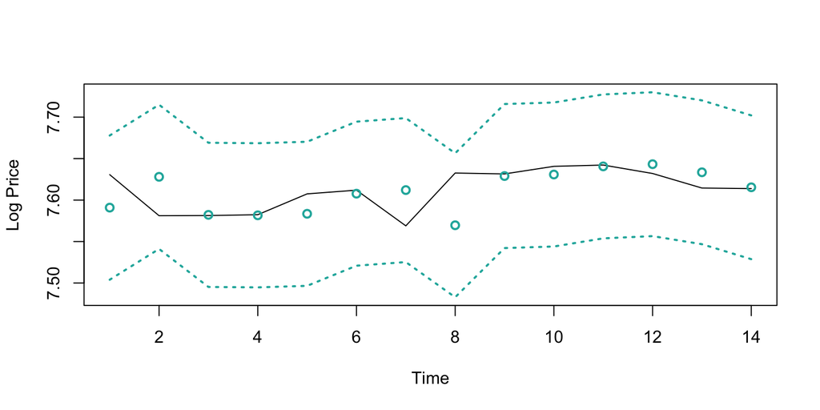

```r
fore.series=ts(fore.series,start=1)
lbound = ts(fore.series-1.96*fore.se,start=1)
ubound = ts(fore.series+1.96*fore.se,start=1)
ymin=min(daily.ts.test,fore.series,lbound,ubound)
ymax=max(daily.ts.test,fore.series,lbound,ubound)
par(mfrow=c(1,1))
plot(ts(daily.ts.test,start=1), ylim=c(ymin,ymax), ylab="Log Price", type="l",main="")
points(fore.series,lwd=2,col=c.col)
lines(lbound,lty=3,lwd= 2, col=c.col)
lines(ubound,lty=3,lwd= 2, col=c.col)
```

```r
cat("MAE:",mean(abs(fore.series-daily.ts.test)),"\n PM:",
sum((fore.series-daily.ts.test)^2)/sum((daily.ts.test-mean(daily.ts.test))^2))
```

```
## MAE: 0.01917298
##  PM: 1.358509
```